# Proyecto final: cobertura de tesorería y financiamiento de The Coca-Cola Company (KO)

Derivados y Administración de Riesgos Corporativos · EGADE Business School

Equipo: Carmen Abigail Cázares Báez · Edgar Jiménez · Diana Lozada

Profesor: Dr. Raymundo Díaz Robles · noviembre de 2026

## Contexto

El proyecto replica para una empresa real la decisión que enfrentó Molson Coors en 2007: cómo financiarse más barato y cubrir los riesgos de tesorería con bonos convertibles, opciones, futuros y swaps. La idea central es que un convertible es un bono recto más una opción call sobre la acción, y que cualquier mejora del cupón o de la prima de conversión tiene un precio en derivados.

Elegimos **The Coca-Cola Company (NYSE: KO, RIC KO.N)** porque cumple todas las reglas. Cotiza en la NYSE y reporta 10-K, 10-Q y 8-K ante la SEC. Tiene 48 bonos vigentes por 41.9 mil millones de dólares en USD, EUR y CHF. Reporta derivados de tipo de cambio, tasa de interés y commodities en las notas de sus estados financieros. Su acción tiene opciones listadas y líquidas. Y tiene una necesidad real de cobertura: 7.7 mil millones de deuda vencen entre noviembre de 2026 y 2028, más de la mitad de sus ingresos son de fuera de EUA y depende de commodities como azúcar, jugos y aluminio.

Los datos provienen de LSEG Workspace (apps SOV, PEERS, Company Fundamentals, Debt Structure, Issuer Ratings y CDS Overview) al 3 de noviembre de 2026 y de Bloomberg (OMON, DES, FA, DDIS, CRPR, USGG5YR y SWPM) al 9 de noviembre de 2026, complementados con el comunicado de resultados del tercer trimestre de 2026 (Form 8-K). Todos los archivos de datos están en la carpeta `datos/` con su fuente en `datos/parametros_mercado.csv`. El dashboard interactivo y la calculadora acompañan a este documento con las mismas cifras.

## 1. Overview de la empresa

```r
mercado <- list(precio = 94.80, cambio = -1.07, ytd = 35.59, mkt_cap = 407.82, pe = 27.94, beta = 0.27,
                div_yield = 2.21, min52 = 67.28, max52 = 96.25, pt_media = 98.38, acciones = 4.30,
                cds5 = 34.564, cds10 = 57.682)
knitr::kable(data.frame(
  Indicador = c("Último precio (USD)", "Rendimiento en el año", "Rango de 52 semanas (USD)", "Market cap (miles de millones USD)",
                "P/E (LTM)", "Beta (5 años)", "Dividend yield", "Precio objetivo medio de analistas (USD)"),
  Valor = c(num(mercado$precio, 2), pct(mercado$ytd), paste(num(mercado$min52, 2), "–", num(mercado$max52, 2)),
            num(mercado$mkt_cap, 1), paste0(num(mercado$pe, 2), "x"), num(mercado$beta, 2), pct(mercado$div_yield, 2),
            num(mercado$pt_media, 2))), align = "lr", row.names = FALSE,
  caption = "LSEG Workspace, apps SOV y PEERS, 3 de noviembre de 2026")
```

LSEG Workspace, apps SOV y PEERS, 3 de noviembre de 2026

| Indicador | Valor |
| --- | --- |
| Último precio (USD) | 94.80 |
| Rendimiento en el año | 35.6 % |
| Rango de 52 semanas (USD) | 67.28 – 96.25 |
| Market cap (miles de millones USD) | 407.8 |
| P/E (LTM) | 27.94x |
| Beta (5 años) | 0.27 |
| Dividend yield | 2.21 % |
| Precio objetivo medio de analistas (USD) | 98.38 |

Coca-Cola vende concentrados, jarabes y bebidas terminadas en más de 200 países, con marcas como Coca-Cola, Sprite, Fanta, Dasani, Powerade, Costa, Minute Maid y fairlife. Opera en dos líneas: concentrados, que vende a sus embotelladoras, y producto terminado. Sus segmentos son EMEA, Latinoamérica, Norteamérica, Asia Pacífico e Inversiones en Embotelladoras. El consenso de analistas es de compra (21 de 27 recomiendan Buy o Strong Buy), con un precio objetivo medio de 98.38 dólares, un 4 % arriba del precio actual.

### Fundamentales 2021–2025

LSEG Company Fundamentals exportó las cifras en millones de pesos mexicanos. Se convierten a dólares con el tipo de cambio que reporta el mismo export: promedio del año para resultados y cierre del año para el balance.

```r
anios  <- 2021:2025
fx_avg <- c(20.2709169863014, 20.0911205479452, 17.7185635616438, 18.3037128415301, 19.1903309589041)
fx_fin <- c(20.487, 19.474, 16.954, 20.8197, 18.0045)
mxn <- data.frame(
  ingresos  = c(783572.30, 863998.55, 810695.16, 861391.03, 920003.66),
  ebitda    = c(255535.18, 268959.83, 254704.35, 278765.55, 308446.19),
  ebit      = c(226101.81, 243645.02, 234717.81, 259089.06, 288296.34),
  util_net  = c(198736.07, 192292.11, 189641.79, 194916.24, 252103.38),
  intereses = c( 19196.56,  17720.37,  27056.25,  30310.95,  31740.81),
  activos   = c(1933030.40, 1806466.66, 1656456.66, 2093400.02, 1887159.67),
  pasivos   = c(1423723.58, 1303531.14, 1190560.74, 1544342.89, 1270055.43),
  capital   = c( 509306.82,  502935.52,  465895.92,  549057.13,  617104.24),
  deuda     = c( 876044.61,  762387.63,  713153.06,  926934.68,  819060.71),
  deuda_cp  = c(  95162.12,   53981.93,  110489.22,   44699.90,   60729.18),
  deuda_lp  = c( 780882.49,  708405.70,  602663.84,  882234.79,  758331.54),
  caja      = c( 258648.38,  226502.09,  231642.50,  303363.85,  284579.13),
  deuda_net = c( 617396.23,  535885.53,  481510.55,  623570.83,  534481.59))
res_cols <- c("ingresos", "ebitda", "ebit", "util_net", "intereses")
fin <- mxn
fin[res_cols] <- mxn[res_cols] / fx_avg / 1000                                   # miles de millones de USD
fin[setdiff(names(mxn), res_cols)] <- mxn[setdiff(names(mxn), res_cols)] / fx_fin / 1000
fin$anio <- anios
fin$de <- fin$deuda / fin$capital
fin$dn_ebitda <- fin$deuda_net / fin$ebitda
fin$d_activos <- fin$deuda / fin$activos

razones <- data.frame(anio = anios,
  margen_bruto  = c(60.27, 58.14, 59.49, 61.06, 61.63), margen_ebitda = c(32.61, 31.13, 31.42, 32.36, 33.53),
  margen_op     = c(28.86, 28.20, 28.95, 30.08, 31.34), margen_neto   = c(25.36, 22.26, 23.39, 22.63, 27.40),
  roe = c(46.20, 40.51, 42.82, 41.86, 45.97), roa = c(10.79, 10.23, 11.24, 10.74, 12.79),
  cob_int = c(11.78, 13.75, 8.68, 8.55, 9.08), razon_circ = c(1.13, 1.15, 1.13, 1.03, 1.46))
u <- fin[fin$anio == 2025, ]; r <- razones[razones$anio == 2025, ]

knitr::kable(data.frame(Año = fin$anio, Ingresos = num(fin$ingresos, 2), EBITDA = num(fin$ebitda, 2),
                        `Utilidad neta` = num(fin$util_net, 2), `Deuda total` = num(fin$deuda, 2),
                        Capital = num(fin$capital, 2), check.names = FALSE),
             align = "lrrrrr", row.names = FALSE, caption = "Miles de millones de USD (LSEG Company Fundamentals)")
```

Miles de millones de USD (LSEG Company Fundamentals)

| Año | Ingresos | EBITDA | Utilidad neta | Deuda total | Capital |
| --- | --- | --- | --- | --- | --- |
| 2021 | 38.66 | 12.61 | 9.80 | 42.76 | 24.86 |
| 2022 | 43.00 | 13.39 | 9.57 | 39.15 | 25.83 |
| 2023 | 45.75 | 14.37 | 10.70 | 42.06 | 27.48 |
| 2024 | 47.06 | 15.23 | 10.65 | 44.52 | 26.37 |
| 2025 | 47.94 | 16.07 | 13.14 | 45.49 | 34.28 |

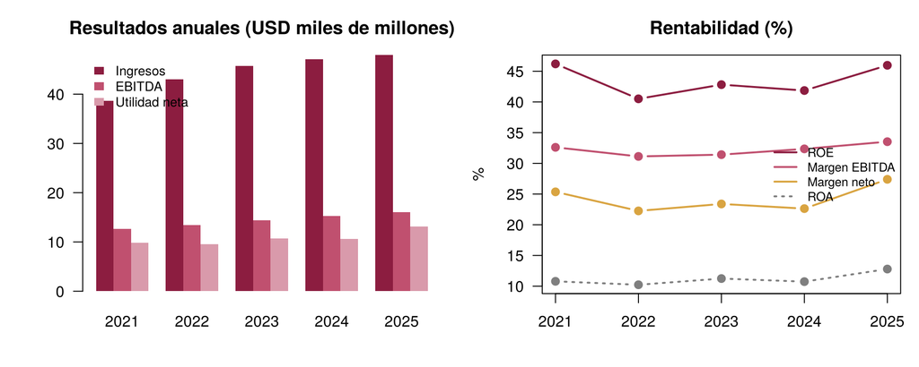

```r
par(mfrow = c(1, 2), mar = c(4, 4.5, 3, 1))
barplot(t(as.matrix(fin[, c("ingresos", "ebitda", "util_net")])), beside = TRUE, names.arg = anios,
        col = BERRY[1:3], border = NA, las = 1, main = "Resultados anuales (USD miles de millones)")
legend("topleft", c("Ingresos", "EBITDA", "Utilidad neta"), fill = BERRY[1:3], border = NA, bty = "n", cex = 0.85)
matplot(anios, razones[, c("roe", "margen_ebitda", "margen_neto", "roa")], type = "b", pch = 19, lty = c(1, 1, 1, 3),
        col = c(BERRY[1], BERRY[2], "#d9a441", "grey50"), lwd = 2, las = 1, xlab = "", ylab = "%", main = "Rentabilidad (%)")
legend("right", c("ROE", "Margen EBITDA", "Margen neto", "ROA"), col = c(BERRY[1], BERRY[2], "#d9a441", "grey50"),
       lty = c(1, 1, 1, 3), lwd = 2, bty = "n", cex = 0.8)
```

**Lectura.** En 2025 Coca-Cola facturó 47.94 mil millones de dólares con un margen EBITDA de 33.5 % y un margen neto de 27.4 %, muy por encima de su industria (8.5 %). Su ROE de 46.0 % es de los más altos del sector de consumo. La rentabilidad se ha mantenido estable cinco años seguidos, que es justo lo que el mercado premia con un P/E alto.

### Año en curso: primeros nueve meses de 2026

```r
res9m <- c(ingresos = 39232, op = 13496, neta = 12358, cfo = 12471, capex = 1063, fcf = 11408)
knitr::kable(data.frame(
  Concepto = c("Ingresos", "Utilidad operativa", "Utilidad neta", "Flujo de operación", "Gasto de capital", "Flujo libre",
               "Margen operativo", "Margen neto"),
  Valor = c(num(res9m[1:6]), pct(100 * res9m["op"] / res9m["ingresos"]), pct(100 * res9m["neta"] / res9m["ingresos"]))),
  align = "lr", row.names = FALSE, caption = "Millones de USD, nueve meses al 2 de octubre de 2026 (Form 8-K del 3T 2026)")
```

Millones de USD, nueve meses al 2 de octubre de 2026 (Form 8-K del 3T 2026)

| Concepto | Valor |
| --- | --- |
| Ingresos | 39,232 |
| Utilidad operativa | 13,496 |
| Utilidad neta | 12,358 |
| Flujo de operación | 12,471 |
| Gasto de capital | 1,063 |
| Flujo libre | 11,408 |
| Margen operativo | 34.4 % |
| Margen neto | 31.5 % |

La empresa subió su guía para 2026: crecimiento orgánico de ingresos de al menos 5 %, crecimiento de la UPA comparable de al menos 11 % y flujo libre de al menos 13 mil millones de dólares.

### Ingresos por segmento

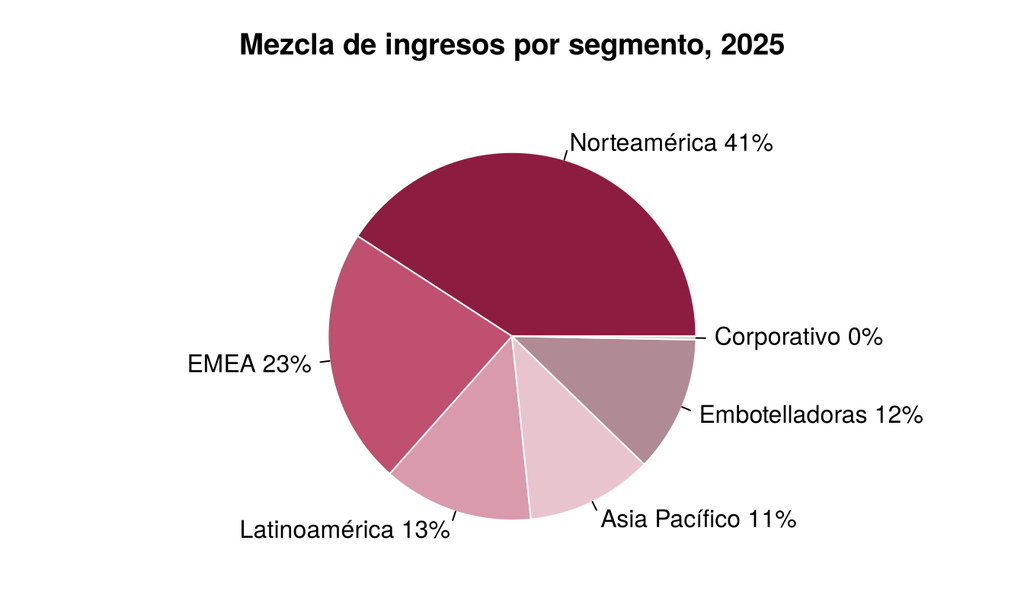

```r
seg <- data.frame(segmento = c("Norteamérica", "EMEA", "Latinoamérica", "Asia Pacífico", "Embotelladoras", "Corporativo"),
                  mxn = c(375727.49, 207888.86, 121493.99, 102246.08, 109883.84, 2763.41))
seg$usd <- seg$mxn / fx_avg[5] / 1000
fuera_eua <- 100 * (1 - seg$usd[1] / sum(seg$usd))
par(mar = c(1, 1, 3, 1))
pie(seg$usd, labels = paste0(seg$segmento, " ", round(100 * seg$usd / sum(seg$usd)), "%"), col = BERRY, border = "white",
    main = "Mezcla de ingresos por segmento, 2025")
```

**Lectura.** Norteamérica genera alrededor del 41 % de los ingresos; el 59 % restante viene de fuera de EUA. Como Coca-Cola reporta en dólares, un dólar fuerte reduce el valor de esos ingresos al convertirlos. Esto justifica el uso de forwards y opciones de tipo de cambio, y que parte de su deuda esté en euros y francos suizos.

## 2. Comparación con pares

```r
peers <- data.frame(
  Ticker  = c("KO.N", "PEP.OQ", "KDP.OQ", "HEIN.AS", "DANO.PA", "DGE.L", "ULVR.L", "NESN.S"),
  Empresa = c("Coca-Cola", "PepsiCo", "Keurig Dr Pepper", "Heineken", "Danone", "Diageo", "Unilever", "Nestlé"),
  PE  = c(27.94, 17.26, 31.35, 19.69, 21.88, 30.37, 24.11, 29.19),
  ROE = c(43.32, 42.85, 8.36, 9.94, 10.84, 14.99, 30.96, 26.53),
  DE  = c(111.36, 232.73, 117.39, 107.96, 100.64, 197.88, 198.28, 215.00))
knitr::kable(setNames(peers, c("Ticker", "Empresa", "P/E (LTM)", "ROE (%)", "D/E (%)")), row.names = FALSE,
             caption = "LSEG PEERS, 3 de noviembre de 2026")
```

LSEG PEERS, 3 de noviembre de 2026

| Ticker | Empresa | P/E (LTM) | ROE (%) | D/E (%) |
| --- | --- | --- | --- | --- |
| KO.N | Coca-Cola | 27.94 | 43.32 | 111.36 |
| PEP.OQ | PepsiCo | 17.26 | 42.85 | 232.73 |
| KDP.OQ | Keurig Dr Pepper | 31.35 | 8.36 | 117.39 |
| HEIN.AS | Heineken | 19.69 | 9.94 | 107.96 |
| DANO.PA | Danone | 21.88 | 10.84 | 100.64 |
| DGE.L | Diageo | 30.37 | 14.99 | 197.88 |
| ULVR.L | Unilever | 24.11 | 30.96 | 198.28 |
| NESN.S | Nestlé | 29.19 | 26.53 | 215.00 |

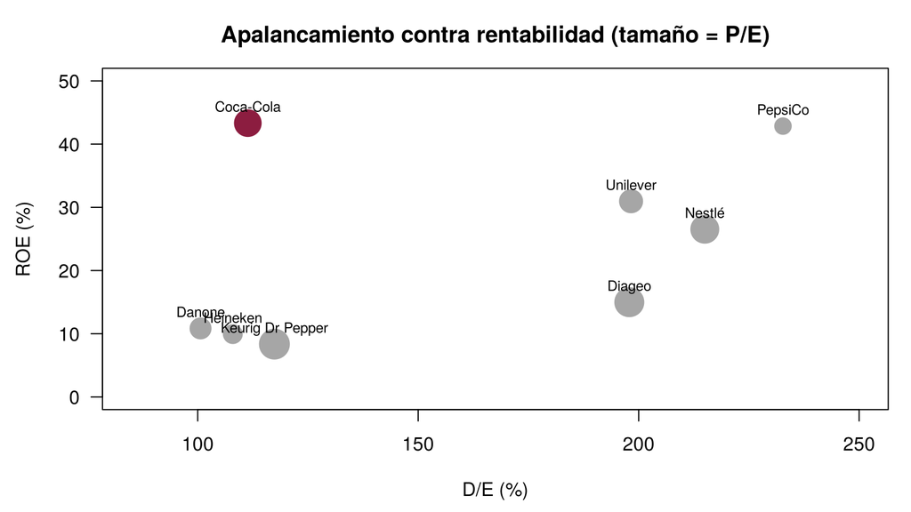

```r
par(mar = c(4.5, 4.5, 3, 1))
plot(peers$DE, peers$ROE, pch = 19, cex = peers$PE / 9, col = ifelse(peers$Ticker == "KO.N", BERRY[1], "grey65"),
     xlab = "D/E (%)", ylab = "ROE (%)", main = "Apalancamiento contra rentabilidad (tamaño = P/E)", las = 1,
     xlim = c(85, 250), ylim = c(0, 50))
text(peers$DE, peers$ROE, peers$Empresa, pos = 3, cex = 0.75)
```

## 3. Estructura de deuda

```r
# Bonos vigentes de LSEG Debt Structure (KO.N, 3-nov-2026). Montos en millones de USD.
bonos <- read.csv("datos/bonos_lseg_ko.csv")
bonos$vencimiento <- as.Date(bonos$vencimiento)
bonos$anio  <- as.integer(format(bonos$vencimiento, "%Y"))
bonos$plazo <- as.numeric(bonos$vencimiento - as.Date("2026-11-03")) / 365.25
total_bonos <- sum(bonos$monto) / 1000
cupon_prom  <- weighted.mean(bonos$cupon, bonos$monto)
plazo_prom  <- weighted.mean(bonos$plazo, bonos$monto)
venc_26_28  <- sum(bonos$monto[bonos$anio <= 2028]) / 1000
por_moneda  <- aggregate(monto ~ moneda, bonos, sum); por_moneda$pct <- 100 * por_moneda$monto / sum(por_moneda$monto)
cupon_moneda <- sapply(split(bonos, bonos$moneda), function(x) weighted.mean(x$cupon, x$monto))

knitr::kable(data.frame(
  Indicador = c("Deuda total (dic-2025, miles de millones USD)", "Deuda de largo plazo / total", "Deuda total (oct-2026, miles de millones USD)",
                "Bonos vigentes (miles de millones USD)", "Número de emisiones", "Cupón promedio ponderado", "Plazo promedio ponderado (años)",
                "Vence entre nov-2026 y 2028 (miles de millones USD)", "Deuda / activos", "Cobertura de intereses (EBIT / intereses)",
                "Deuda neta / EBITDA", "Razón circulante"),
  Valor = c(num(u$deuda, 2), pct(100 * u$deuda_lp / u$deuda, 0), num((73 + 4923 + 36623) / 1000, 2),
            num(total_bonos, 1), nrow(bonos), pct(cupon_prom, 2), num(plazo_prom, 1), num(venc_26_28, 2),
            pct(100 * u$d_activos), paste0(num(r$cob_int, 1), "x"), paste0(num(u$dn_ebitda, 2), "x"),
            paste0(num(r$razon_circ, 2), "x"))), align = "lr", row.names = FALSE,
  caption = "LSEG Debt Structure y Company Fundamentals; deuda a oct-2026 del 8-K del 3T 2026")
```

LSEG Debt Structure y Company Fundamentals; deuda a oct-2026 del 8-K del 3T 2026

| Indicador | Valor |
| --- | --- |
| Deuda total (dic-2025, miles de millones USD) | 45.49 |
| Deuda de largo plazo / total | 93 % |
| Deuda total (oct-2026, miles de millones USD) | 41.62 |
| Bonos vigentes (miles de millones USD) | 41.9 |
| Número de emisiones | 48 |
| Cupón promedio ponderado | 2.46 % |
| Plazo promedio ponderado (años) | 11.7 |
| Vence entre nov-2026 y 2028 (miles de millones USD) | 7.71 |
| Deuda / activos | 43.4 % |
| Cobertura de intereses (EBIT / intereses) | 9.1x |
| Deuda neta / EBITDA | 1.85x |
| Razón circulante | 1.46x |

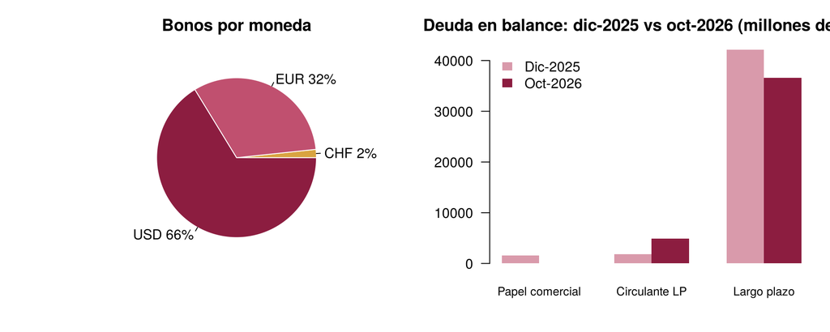

```r
par(mfrow = c(1, 2), mar = c(4, 4.5, 3, 1))
pie(por_moneda$monto, labels = paste0(por_moneda$moneda, " ", round(por_moneda$pct), "%"),
    col = COL_MON[por_moneda$moneda], border = "white", main = "Bonos por moneda")
m <- rbind(c(1551, 1822, 42119), c(73, 4923, 36623))
barplot(m, beside = TRUE, names.arg = c("Papel comercial", "Circulante LP", "Largo plazo"), col = BERRY[c(3, 1)],
        border = NA, las = 1, cex.names = 0.85, main = "Deuda en balance: dic-2025 vs oct-2026 (millones de USD)")
legend("topleft", c("Dic-2025", "Oct-2026"), fill = BERRY[c(3, 1)], border = NA, bty = "n")
```

**Lectura.** Coca-Cola tiene 48 bonos vigentes por 41.9 mil millones de dólares, con un cupón promedio de apenas 2.46 % y un plazo promedio de 11.7 años, porque la mayor parte se emitió con tasas bajas entre 2020 y 2021. El 66 % está en dólares, el 32 % en euros (cupón promedio de 1.28 %) y el 2 % en francos suizos. Eso crea una cobertura natural parcial frente a sus ingresos en Europa, pero también exposición cambiaria en el principal. Con cobertura de intereses de 9.1x y deuda neta/EBITDA de 1.85x hay holgura amplia para emitir. Entre diciembre de 2025 y octubre de 2026 la empresa pagó casi todo su papel comercial y la porción que vence en doce meses subió de 1.8 a 4.9 mil millones.

## 4. Calendario de vencimientos

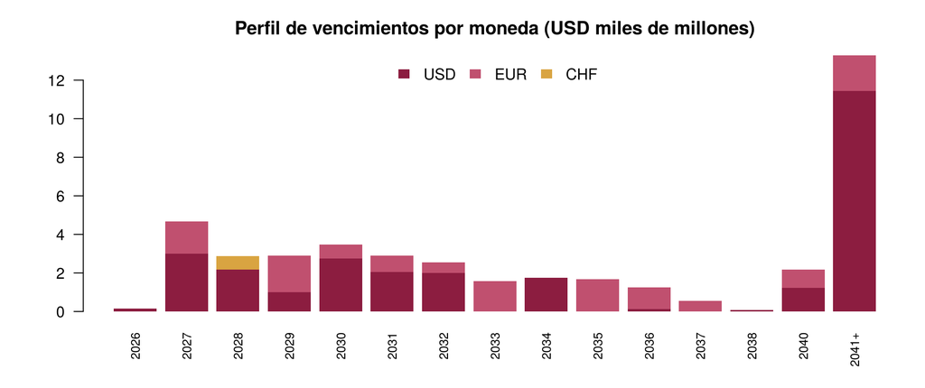

```r
bonos$cubeta <- ifelse(bonos$anio <= 2040, as.character(bonos$anio), "2041+")
perfil <- tapply(bonos$monto / 1000, list(bonos$moneda, factor(bonos$cubeta, levels = sort(unique(bonos$cubeta)))), sum)
perfil[is.na(perfil)] <- 0
perfil <- perfil[c("USD", "EUR", "CHF"), ]
par(mar = c(4, 4.5, 3, 1))
barplot(perfil, col = COL_MON[rownames(perfil)], border = NA, las = 2, cex.names = 0.8,
        main = "Perfil de vencimientos por moneda (USD miles de millones)")
legend("top", rownames(perfil), fill = COL_MON[rownames(perfil)], border = NA, bty = "n", horiz = TRUE)
```

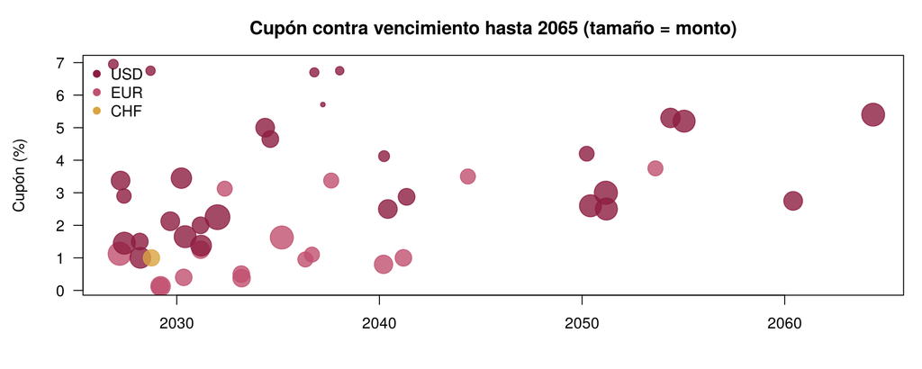

```r
b <- bonos[bonos$anio < 2066, ]
par(mar = c(4, 4.5, 3, 1))
plot(b$vencimiento, b$cupon, pch = 19, cex = 0.6 + sqrt(b$monto) / 15, col = adjustcolor(COL_MON[b$moneda], 0.8),
     xlab = "", ylab = "Cupón (%)", las = 1, main = "Cupón contra vencimiento hasta 2065 (tamaño = monto)")
legend("topleft", names(COL_MON), col = COL_MON, pch = 19, bty = "n")
```

```r
prox <- bonos[bonos$anio <= 2028, c("vencimiento", "moneda", "cupon", "monto")]
knitr::kable(transform(prox, vencimiento = format(vencimiento, "%d-%b-%Y"), cupon = num(cupon, 3), monto = num(monto, 1)),
             col.names = c("Vencimiento", "Moneda", "Cupón (%)", "Monto (USD M)"), align = "llrr", row.names = FALSE,
             caption = "Próximos vencimientos (2026–2028): la deuda que hay que refinanciar")
```

Próximos vencimientos (2026–2028): la deuda que hay que refinanciar

| Vencimiento | Moneda | Cupón (%) | Monto (USD M) |
| --- | --- | --- | --- |
| 15-Nov-2026 | USD | 6.950 | 151.7 |
| 09-Mar-2027 | EUR | 1.125 | 1,679.0 |
| 25-Mar-2027 | USD | 3.375 | 1,000.0 |
| 25-May-2027 | USD | 2.900 | 500.0 |
| 01-Jun-2027 | USD | 1.450 | 1,500.0 |
| 05-Mar-2028 | USD | 1.500 | 750.0 |
| 15-Mar-2028 | USD | 1.000 | 1,300.0 |
| 15-Sep-2028 | USD | 6.750 | 131.4 |
| 02-Oct-2028 | CHF | 1.000 | 700.7 |

**Lectura.** Entre noviembre de 2026 y 2028 vencen 7.71 mil millones de dólares, en su mayoría con cupones de 1.0 % a 3.4 %. Refinanciarlos hoy con deuda recta costaría bastante más que su cupón actual. Es el mismo problema que en 2007 resolvió Molson Coors con un convertible.

## 5. Calificación crediticia y riesgo de crédito

```r
calif <- data.frame(
  Agencia = c("S&P", "S&P", "Moody's", "Moody's", "Fitch", "Egan-Jones"),
  Tipo = c("Largo plazo emisor / senior no garantizado", "Corto plazo / papel comercial", "Senior no garantizado",
           "Corto plazo / papel comercial", "Largo plazo (IDR)", "Senior no garantizado"),
  Calificación = c("A+", "A-1", "A1", "P-1", "WD (retirada)", "A"),
  Desde = c("26-abr-2018", "26-abr-2018", "20-nov-2018", "06-jun-2023", "15-nov-2023", "03-ago-2016"),
  Perspectiva = c("Estable", "—", "Estable", "Estable", "—", "—"))
knitr::kable(calif, row.names = FALSE, caption = "LSEG Issuer Ratings, 3 de noviembre de 2026")
```

LSEG Issuer Ratings, 3 de noviembre de 2026

| Agencia | Tipo | Calificación | Desde | Perspectiva |
| --- | --- | --- | --- | --- |
| S&P | Largo plazo emisor / senior no garantizado | A+ | 26-abr-2018 | Estable |
| S&P | Corto plazo / papel comercial | A-1 | 26-abr-2018 | — |
| Moody’s | Senior no garantizado | A1 | 20-nov-2018 | Estable |
| Moody’s | Corto plazo / papel comercial | P-1 | 06-jun-2023 | Estable |
| Fitch | Largo plazo (IDR) | WD (retirada) | 15-nov-2023 | — |
| Egan-Jones | Senior no garantizado | A | 03-ago-2016 | — |

```r
knitr::kable(data.frame(Indicador = c("CDS a 5 años (pb)", "CDS a 10 años (pb)", "StarMine credit risk"),
                        Valor = c(num(mercado$cds5, 1), num(mercado$cds10, 1), "95 / 100")),
             align = "lr", row.names = FALSE, caption = "LSEG CDS Overview (Markit, senior, USD) y StarMine")
```

LSEG CDS Overview (Markit, senior, USD) y StarMine

| Indicador | Valor |
| --- | --- |
| CDS a 5 años (pb) | 34.6 |
| CDS a 10 años (pb) | 57.7 |
| StarMine credit risk | 95 / 100 |

**Lectura.** Coca-Cola mantiene grado de inversión alto (A+ / A1) sin cambios desde 2018, con perspectiva estable. El CDS a 5 años en 34.6 pb confirma un riesgo de crédito muy bajo y sirve como estimación del diferencial de crédito que se suma a la tasa del Tesoro para valuar el componente de bono recto del convertible. Fitch retiró su calificación en 2023 a petición del emisor, así que las referencias relevantes son S&P y Moody’s. Un convertible senior no garantizado tendría la misma calificación que la deuda actual.

### Validación con Bloomberg

```r
knitr::kable(data.frame(
  Indicador = c("Deuda en bonos (miles de millones USD)", "Número de emisiones", "Cupón promedio ponderado", "Plazo promedio ponderado (años)",
                "Deuda total en balance, 3T 2026 (miles de millones USD)", "Calificación Moody's / S&P", "Probabilidad de incumplimiento a 1 año implícita en el mercado"),
  LSEG = c(num(total_bonos, 1), nrow(bonos), pct(cupon_prom, 2), num(plazo_prom, 1), "41.6 (8-K)", "A1 / A+", "—"),
  Bloomberg = c("42.5 (DDIS, solo principal)", "53", "2.46 %", "11.5", "41.6 (FA)", "A1 / A+ (CRPR)", "0.21 % (MIPD), categoría IG1"),
  check.names = FALSE), align = "lrr", row.names = FALSE, caption = "Bloomberg DDIS, CRPR y FA, 9 de noviembre de 2026")
```

Bloomberg DDIS, CRPR y FA, 9 de noviembre de 2026

| Indicador | LSEG | Bloomberg |
| --- | --- | --- |
| Deuda en bonos (miles de millones USD) | 41.9 | 42.5 (DDIS, solo principal) |
| Número de emisiones | 48 | 53 |
| Cupón promedio ponderado | 2.46 % | 2.46 % |
| Plazo promedio ponderado (años) | 11.7 | 11.5 |
| Deuda total en balance, 3T 2026 (miles de millones USD) | 41.6 (8-K) | 41.6 (FA) |
| Calificación Moody’s / S&P | A1 / A+ | A1 / A+ (CRPR) |
| Probabilidad de incumplimiento a 1 año implícita en el mercado | — | 0.21 % (MIPD), categoría IG1 |

**Lectura.** Las dos fuentes coinciden en lo esencial: mismo cupón promedio, plazo casi igual y la misma calificación. La diferencia de unos 600 millones y cinco emisiones viene de notas a tasa flotante que Bloomberg incluye en DDIS y que no estaban en la lista de LSEG; con ellas, **2027 es el año de mayores vencimientos (≈ 5.3 mil millones)**, justo el bloque que proponemos refinanciar. Bloomberg ubica a KO en IG1, su categoría de menor riesgo, con una probabilidad de incumplimiento a un año de 0.21 %, consistente con el CDS de 34.6 pb.

## 6. Cotización y volatilidad de KO

La volatilidad de la acción es el dato que más pesa en la valuación del convertible, porque define cuánto vale la opción que se le entrega al inversionista. Esta sección compara la volatilidad histórica, EWMA y GARCH(1,1) de KO con la volatilidad implícita que reporta Bloomberg.

```r
library(quantmod)
ko <- tryCatch(getSymbols("KO", src = "yahoo", from = "2021-11-01", to = "2026-11-10", auto.assign = FALSE),
               error = function(e) NULL)
# Resultados de la misma estimación corrida en Google Colab con datos de Yahoo Finance (respaldo sin conexión)
vol_colab <- c(hist5 = 0.1684, hist30 = 0.1980, ewma = 0.1987, garch_lp = 0.1740, garch5 = 0.1741)
garch_colab <- c(omega = 4.82e-06, alpha = 0.0669, beta = 0.8930)
if (!is.null(ko)) {
  p <- Ad(ko); rr <- as.numeric(na.omit(diff(log(p)))); x <- rr - mean(rr)
  ewma <- numeric(length(x)); ewma[1] <- var(x)
  for (t in 2:length(x)) ewma[t] <- 0.94 * ewma[t - 1] + 0.06 * x[t - 1]^2
  nll <- function(th) { w <- th[1]; a <- th[2]; b <- th[3]
    if (w <= 0 || a < 0 || b < 0 || a + b >= 1) return(1e10)
    v <- numeric(length(x)); v[1] <- var(x)
    for (t in 2:length(x)) v[t] <- w + a * x[t - 1]^2 + b * v[t - 1]
    0.5 * sum(log(2 * pi * v) + x^2 / v) }
  fit <- optim(c(var(x) * 0.05, 0.08, 0.90), nll, control = list(maxit = 4000))
  w <- fit$par[1]; a <- fit$par[2]; b <- fit$par[3]; VL <- w / (1 - a - b)
  v <- numeric(length(x)); v[1] <- var(x); for (t in 2:length(x)) v[t] <- w + a * x[t - 1]^2 + b * v[t - 1]
  h <- 1:(252 * 5); vf <- VL + (a + b)^(h - 1) * (w + a * x[length(x)]^2 + b * v[length(v)] - VL)
  vol_colab <- c(hist5 = sd(rr) * sqrt(252), hist30 = sd(tail(rr, 30)) * sqrt(252), ewma = sqrt(ewma[length(ewma)] * 252),
                 garch_lp = sqrt(VL * 252), garch5 = sqrt(mean(vf) * 252))
  garch_colab <- c(omega = w, alpha = a, beta = b)
  par(mfrow = c(1, 2), mar = c(3, 4.5, 3, 1))
  plot(index(p), as.numeric(p), type = "l", col = BERRY[1], lwd = 1.5, xlab = "", ylab = "USD", las = 1, main = "KO: precio ajustado (5 años)")
  fechas <- index(p)[-1]
  plot(fechas, sqrt(v * 252) * 100, type = "l", col = BERRY[1], lwd = 1.3, xlab = "", ylab = "%", las = 1, main = "Volatilidad GARCH(1,1) vs. implícita")
  lines(fechas, sqrt(ewma * 252) * 100, col = BERRY[3])
  abline(h = 20.18, lty = 2, col = "#d9a441", lwd = 2)
  legend("topright", c("GARCH(1,1)", "EWMA", "Implícita Bloomberg"), col = c(BERRY[1], BERRY[3], "#d9a441"), lty = c(1, 1, 2), bty = "n", cex = 0.8)
  fuente_vol <- "Yahoo Finance vía quantmod"
} else {
  fuente_vol <- "Google Colab con datos de Yahoo Finance, 9-nov-2026 (este documento se compiló sin conexión)"
  cat("Sin conexión a Yahoo Finance al compilar: se muestran los resultados de la misma estimación corrida en Colab.\n")
}
```

```
## Sin conexión a Yahoo Finance al compilar: se muestran los resultados de la misma estimación corrida en Colab.
```

```r
knitr::kable(data.frame(
  Medida = c("Histórica 5 años", "Histórica 30 días", "EWMA (λ = 0.94)", "GARCH(1,1) de largo plazo", "GARCH(1,1) promedio a 5 años",
             "Implícita Bloomberg, strike 120 (ene-2029)"),
  `Volatilidad anual` = pct(100 * c(vol_colab, 0.2018)), check.names = FALSE), align = "lr", row.names = FALSE,
  caption = paste0("Fuente: ", fuente_vol, "; Bloomberg OMON. GARCH: ω = ", formatC(garch_colab[["omega"]], format = "e", digits = 2),
                   ", α = ", num(garch_colab[["alpha"]], 4), ", β = ", num(garch_colab[["beta"]], 4),
                   ", persistencia = ", num(garch_colab[["alpha"]] + garch_colab[["beta"]], 4)))
```

Fuente: Google Colab con datos de Yahoo Finance, 9-nov-2026 (este documento se compiló sin conexión); Bloomberg OMON. GARCH: ω = 4.82e-06, α = 0.0669, β = 0.8930, persistencia = 0.9599

| Medida | Volatilidad anual |
| --- | --- |
| Histórica 5 años | 16.8 % |
| Histórica 30 días | 19.8 % |
| EWMA (λ = 0.94) | 19.9 % |
| GARCH(1,1) de largo plazo | 17.4 % |
| GARCH(1,1) promedio a 5 años | 17.4 % |
| Implícita Bloomberg, strike 120 (ene-2029) | 20.2 % |

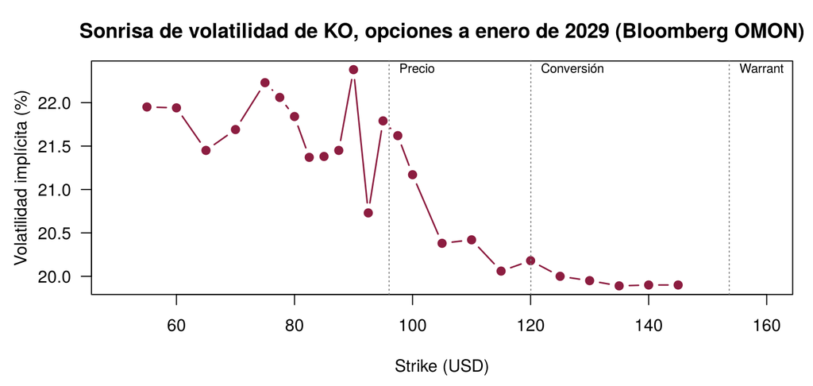

```r
omon <- read.csv("datos/bloomberg_omon_ko_ene2029.csv")
par(mar = c(4.5, 4.5, 3, 1))
plot(omon$strike, omon$ivm_call, type = "b", pch = 19, col = BERRY[1], lwd = 1.5, las = 1, xlab = "Strike (USD)",
     ylab = "Volatilidad implícita (%)", main = "Sonrisa de volatilidad de KO, opciones a enero de 2029 (Bloomberg OMON)", xlim = c(50, 160))
abline(v = c(96.03, 120.04, 153.65), lty = 3, col = "grey50")
text(c(96.03, 120.04, 153.65), max(omon$ivm_call), c("Precio", "Conversión", "Warrant"), pos = 4, cex = 0.75)
```

**Lectura.** La volatilidad implícita de Bloomberg para el strike del precio de conversión (20.2 %) está unos 2.8 puntos por encima del pronóstico GARCH a cinco años (17.4 %) y en línea con la volatilidad reciente (EWMA de 19.9 %). La persistencia del GARCH de 0.96 indica que los choques de volatilidad se disipan en pocos meses. Para Coca-Cola esto es una buena noticia: el mercado le paga una volatilidad relativamente alta por la opción que entrega en el convertible, y también por los warrants que vende. La curva de volatilidad baja en los strikes altos (sesgo típico de acciones), por lo que el warrant se valúa con 19.9 %, un poco menos que las calls a 120.

## 7. Riesgos de tesorería y necesidad de cobertura

| Riesgo | Nivel | Origen | Instrumentos |
| --- | --- | --- | --- |
| Tasa / refinanciamiento | Alto | 7.7 mil millones vencen entre 2026 y 2028 con cupones de 1.0 % a 3.4 %, por debajo de lo que pagaría hoy en deuda recta | Convertible para bajar el cupón; T-lock o swap de inicio diferido antes de emitir; IRS para mezclar tasa fija y flotante |
| Tipo de cambio | Medio-alto | 59 % de los ingresos y 34 % de los bonos están fuera de USD | Forwards y opciones de divisas sobre flujos esperados; cross-currency swaps para la deuda en EUR y CHF |
| Commodities | Medio | Azúcar, jarabe de maíz, jugo de naranja, café y aluminio para latas | Futuros y swaps de commodities (azúcar No. 11 en ICE, aluminio en CME/LME) |
| Crédito | Bajo | A+ / A1 estable y CDS a 5 años de 34.6 pb | Capacidad para emitir sin poner en riesgo la calificación |

El uso de derivados que reporta Coca-Cola está en la nota “Hedging Transactions and Derivative Financial Instruments” de su 10-K; los nocionales por tipo se validarán con el 10-K del ejercicio 2025.

## 8. Propuesta de financiamiento y cobertura

```r
prima_conv <- 0.25; prima_techo <- 0.60
monto_emision <- 3000e6   # Bonos en USD que vencen entre marzo y junio de 2027
S0 <- 96.03               # Precio de KO al 9-nov-2026 (Bloomberg OMON)
propuesta <- data.frame(
  Elemento = c("Instrumento", "Monto", "Uso de fondos", "Precio de conversión", "Call spread", "Cobertura de tasa",
               "Cobertura cambiaria", "Beneficio buscado"),
  `Molson Coors (2007)` = c("Convertible senior no garantizado a 6 años", "$500M ampliado a $575M",
                            "Recomprar bonos 6.38 % a 2012 y fondear pensiones", "25 % sobre $87.61 = $109.51",
                            "Calls al 25 % y warrants al 60 % ($140.18)", "T-lock (ganancia de $1.4M)", "—",
                            "~$15M menos de gasto financiero al año"),
  `Coca-Cola (propuesta)` = c("Convertible senior no garantizado a 5 años", "$3.0B",
                              "Refinanciar los bonos en USD de mar–jun 2027 ($3.0B)",
                              sprintf("%.0f %% sobre $%.2f = $%.2f", 100 * prima_conv, S0, S0 * (1 + prima_conv)),
                              sprintf("Calls a $%.2f y warrants al %.0f %% ($%.2f)", S0 * (1 + prima_conv), 100 * prima_techo, S0 * (1 + prima_techo)),
                              "T-lock sobre el Tesoro a 5 años durante la colocación",
                              "Cross-currency swap para refinanciar el bono EUR de mar-2027 ($1.68B equivalentes)",
                              "Cupón menor que la deuda recta y dilución controlada con el call spread"),
  check.names = FALSE)
knitr::kable(propuesta, row.names = FALSE, caption = "Estructura propuesta con el caso Molson Coors como modelo")
```

Estructura propuesta con el caso Molson Coors como modelo

| Elemento | Molson Coors (2007) | Coca-Cola (propuesta) |
| --- | --- | --- |
| Instrumento | Convertible senior no garantizado a 6 años | Convertible senior no garantizado a 5 años |
| Monto | $500M ampliado a $575M | $3.0B |
| Uso de fondos | Recomprar bonos 6.38 % a 2012 y fondear pensiones | Refinanciar los bonos en USD de mar–jun 2027 ($3.0B) |
| Precio de conversión | 25 % sobre $87.61 = $109.51 | 25 % sobre $96.03 = $120.04 |
| Call spread | Calls al 25 % y warrants al 60 % ($140.18) | Calls a $120.04 y warrants al 60 % ($153.65) |
| Cobertura de tasa | T-lock (ganancia de $1.4M) | T-lock sobre el Tesoro a 5 años durante la colocación |
| Cobertura cambiaria | — | Cross-currency swap para refinanciar el bono EUR de mar-2027 ($1.68B equivalentes) |
| Beneficio buscado | ~$15M menos de gasto financiero al año | Cupón menor que la deuda recta y dilución controlada con el call spread |

**Por qué un convertible y no deuda recta o capital.** Frente a deuda recta, el convertible paga un cupón menor porque el inversionista recibe una opción sobre la acción; a cambio, Coca-Cola acepta una posible dilución futura. Frente a emitir acciones, la dilución solo ocurre si la acción sube por encima del precio de conversión y, con el call spread, solo por encima del techo de 60 %. La desventaja es la complejidad: el ahorro de cupón se paga con la opción entregada y con el costo del call spread.

## 9. Parámetros de mercado para la valuación

```r
# Volatilidades implícitas IVM de Bloomberg OMON, opciones de KO a ene-2029 (802 días), 9-nov-2026
sigma   <- 0.2018              # Strike 120 = precio de conversión
sigma_w <- 0.1990              # Strike ≈ 154 = warrant (IVM de 19.9 % en los strikes 140-145)
sigma_atm <- 0.2179            # Strike 95, cerca del dinero (referencia)
q      <- mercado$div_yield / 100   # Rendimiento por dividendo (LSEG SOV)
rf     <- 0.046767             # Tesoro a 5 años (Bloomberg USGG5YR, 9-nov-2026)
swap5  <- 0.043975             # Swap SOFR a 5 años (Bloomberg SWPM)
dv01_10mm <- 4456.30           # DV01 de un swap a 5 años por 10 millones (Bloomberg SWPM)
spread <- mercado$cds5 / 10000 # CDS a 5 años como diferencial de crédito (LSEG CDS Overview)
plazo  <- 5
nominal_bono <- 1000
y_recta <- rf + spread

knitr::kable(data.frame(
  Parámetro = c("Precio de KO", "Volatilidad implícita strike 120 / warrant", "Dividendo", "Tesoro 5 años", "Swap SOFR 5 años", "Diferencial de crédito (CDS 5 años)",
                "Rendimiento de la deuda recta", "Plazo", "Monto de la emisión"),
  Valor = c(num(S0, 2), paste(pct(100 * sigma), "/", pct(100 * sigma_w)), pct(100 * q, 2), pct(100 * rf, 2), pct(100 * swap5, 2), paste(num(mercado$cds5, 1), "pb"),
            pct(100 * y_recta, 2), paste(plazo, "años"), paste(num(monto_emision / 1e6), "millones USD")),
  Fuente = c("Bloomberg OMON, 9-nov-2026", "Bloomberg OMON, ene-2029", "LSEG SOV y Bloomberg DES", "Bloomberg USGG5YR, 9-nov-2026", "Bloomberg SWPM, 9-nov-2026", "LSEG CDS Overview",
             "Tesoro + CDS", "Supuesto", "LSEG Debt Structure")), align = "lll", row.names = FALSE)
```

| Parámetro | Valor | Fuente |
| --- | --- | --- |
| Precio de KO | 96.03 | Bloomberg OMON, 9-nov-2026 |
| Volatilidad implícita strike 120 / warrant | 20.2 % / 19.9 % | Bloomberg OMON, ene-2029 |
| Dividendo | 2.21 % | LSEG SOV y Bloomberg DES |
| Tesoro 5 años | 4.68 % | Bloomberg USGG5YR, 9-nov-2026 |
| Swap SOFR 5 años | 4.40 % | Bloomberg SWPM, 9-nov-2026 |
| Diferencial de crédito (CDS 5 años) | 34.6 pb | LSEG CDS Overview |
| Rendimiento de la deuda recta | 5.02 % | Tesoro + CDS |
| Plazo | 5 años | Supuesto |
| Monto de la emisión | 3,000 millones USD | LSEG Debt Structure |

## 10. Valuación del convertible: bono recto más opción

Un convertible es un bono recto más una opción call sobre la acción. El cupón justo es el que hace que el bono recto más la opción valgan exactamente el nominal. La opción se valúa con Black-Scholes y se comprueba con un árbol binomial CRR, en su versión europea y americana.

```r
bs_call <- function(S, K, T, r, q, s) {
  d1 <- (log(S / K) + (r - q + s^2 / 2) * T) / (s * sqrt(T)); d2 <- d1 - s * sqrt(T)
  S * exp(-q * T) * pnorm(d1) - K * exp(-r * T) * pnorm(d2)
}
bs_greeks <- function(S, K, T, r, q, s) {
  d1 <- (log(S / K) + (r - q + s^2 / 2) * T) / (s * sqrt(T))
  c(delta = exp(-q * T) * pnorm(d1),
    gamma = exp(-q * T) * dnorm(d1) / (S * s * sqrt(T)),
    vega  = S * exp(-q * T) * dnorm(d1) * sqrt(T) / 100)
}
crr_call <- function(S, K, T, r, q, s, N = 500, americana = TRUE) {
  dt <- T / N; u <- exp(s * sqrt(dt)); d <- 1 / u; p <- (exp((r - q) * dt) - d) / (u - d)
  V <- pmax(S * u^(0:N) * d^(N:0) - K, 0)
  for (i in (N - 1):0) {
    V <- exp(-r * dt) * (p * V[2:(i + 2)] + (1 - p) * V[1:(i + 1)])
    if (americana) V <- pmax(V, S * u^(0:i) * d^(i:0) - K)
  }
  V[1]
}
bono_recto <- function(cupon, y, T, F = 1000) sum(cupon * F / (1 + y)^(1:T)) + F / (1 + y)^T
```

```r
K_conv   <- S0 * (1 + prima_conv)
ratio    <- nominal_bono / K_conv
call_bs  <- bs_call(S0, K_conv, plazo, rf, q, sigma)
call_eur <- crr_call(S0, K_conv, plazo, rf, q, sigma, americana = FALSE)
call_am  <- crr_call(S0, K_conv, plazo, rf, q, sigma, americana = TRUE)
valor_opcion <- ratio * call_bs
cupon_justo  <- uniroot(function(c) bono_recto(c, y_recta, plazo) + valor_opcion - nominal_bono, c(-0.05, 0.2))$root
ahorro_anual <- (y_recta - cupon_justo) * monto_emision

knitr::kable(data.frame(
  Concepto = c("Precio de conversión", "Acciones por bono", "Call europea (Black-Scholes)", "Call europea (árbol CRR, N = 500)",
               "Call americana (árbol CRR, N = 500)", "Valor de la opción por bono", "Bono recto (sin opción) al cupón justo",
               "Cupón justo del convertible", "Rendimiento de la deuda recta", "Ahorro anual de intereses (millones USD)"),
  Valor = c(num(K_conv, 2), num(ratio, 3), num(call_bs, 2), num(call_eur, 2), num(call_am, 2), num(valor_opcion, 2),
            num(bono_recto(cupon_justo, y_recta, plazo), 2), pct(100 * cupon_justo, 2), pct(100 * y_recta, 2),
            num(ahorro_anual / 1e6, 1))), align = "lr", row.names = FALSE)
```

| Concepto | Valor |
| --- | --- |
| Precio de conversión | 120.04 |
| Acciones por bono | 8.331 |
| Call europea (Black-Scholes) | 12.03 |
| Call europea (árbol CRR, N = 500) | 12.03 |
| Call americana (árbol CRR, N = 500) | 12.05 |
| Valor de la opción por bono | 100.20 |
| Bono recto (sin opción) al cupón justo | 899.80 |
| Cupón justo del convertible | 2.71 % |
| Rendimiento de la deuda recta | 5.02 % |
| Ahorro anual de intereses (millones USD) | 69.5 |

**Lectura.** Con una prima de conversión de 25 %, el cupón justo del convertible es de 2.71 %, contra 5.02 % que pagaría Coca-Cola en deuda recta a cinco años. La diferencia representa un ahorro de unos 69.5 millones de dólares al año sobre una emisión de 3.0 mil millones, equivalente a 2.3 % de la emisión por año. En proporción es algo menor que el de Molson Coors (≈ 15 millones sobre 575, 2.6 %), porque Coca-Cola ya se financia muy barato: su diferencial de crédito es de apenas 34.6 pb. Para dimensionarlo: el ahorro equivale a cerca del 4.2 % de todo el gasto por intereses de Coca-Cola en 2025 (1,653 millones según Bloomberg FA). El ahorro no es gratis: el inversionista acepta un cupón menor porque recibe una opción que vale 100.20 dólares por bono, es decir, el 10.0 % del nominal. La call americana vale casi lo mismo que la europea (12.05 contra 12.03): con un dividendo de 2.21 % casi nunca conviene ejercer antes del vencimiento, así que Black-Scholes es una buena aproximación.

### Árbol binomial: convergencia y primeros nodos

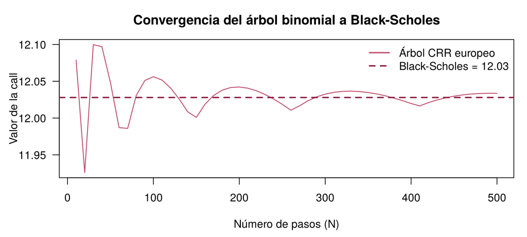

```r
Ns <- seq(10, 500, 10)
conv <- sapply(Ns, function(n) crr_call(S0, K_conv, plazo, rf, q, sigma, N = n, americana = FALSE))
par(mar = c(4.5, 4.5, 3, 1))
plot(Ns, conv, type = "l", col = BERRY[2], lwd = 1.3, las = 1, xlab = "Número de pasos (N)", ylab = "Valor de la call",
     main = "Convergencia del árbol binomial a Black-Scholes")
abline(h = call_bs, lty = 2, col = BERRY[1], lwd = 2)
legend("topright", c("Árbol CRR europeo", paste0("Black-Scholes = ", num(call_bs, 2))), col = BERRY[2:1], lty = c(1, 2), lwd = 2, bty = "n")
```

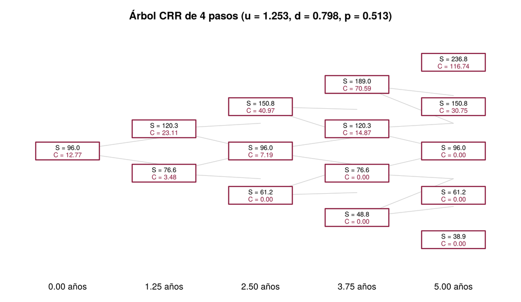

```r
N4 <- 4; dt4 <- plazo / N4; u <- exp(sigma * sqrt(dt4)); d <- 1 / u; p4 <- (exp((rf - q) * dt4) - d) / (u - d)
Sn <- lapply(0:N4, function(i) S0 * u^(0:i) * d^(i:0))
Vn <- vector("list", N4 + 1); Vn[[N4 + 1]] <- pmax(Sn[[N4 + 1]] - K_conv, 0); ejer <- vector("list", N4 + 1)
for (i in N4:1) {
  cont <- exp(-rf * dt4) * (p4 * Vn[[i + 1]][-1] + (1 - p4) * Vn[[i + 1]][-(i + 1)])
  ej <- Sn[[i]] - K_conv; Vn[[i]] <- pmax(cont, ej); ejer[[i]] <- ej > cont
}
par(mar = c(3, 1, 3, 1))
plot(NA, xlim = c(-0.4, N4 + 0.4), ylim = c(-N4 / 2 - 0.5, N4 / 2 + 0.5) * 1.6, axes = FALSE, xlab = "", ylab = "",
     main = sprintf("Árbol CRR de 4 pasos (u = %.3f, d = %.3f, p = %.3f)", u, d, p4))
for (i in 0:N4) for (j in 0:i) {
  y <- (j - i / 2) * 1.6
  if (i < N4) segments(i, y, i + 1, c(j, j + 1) - (i + 1) / 2, col = "grey80")
}
for (i in 0:N4) for (j in 0:i) {
  y <- (j - i / 2) * 1.6
  col <- if (i < N4 && isTRUE(ejer[[i + 1]][j + 1])) "#d9a441" else BERRY[1]
  rect(i - 0.33, y - 0.32, i + 0.33, y + 0.32, col = "white", border = col, lwd = 2)
  text(i, y + 0.12, paste0("S = ", num(Sn[[i + 1]][j + 1], 1)), cex = 0.75)
  text(i, y - 0.14, paste0("C = ", num(Vn[[i + 1]][j + 1], 2)), cex = 0.75, col = BERRY[1])
}
axis(1, at = 0:N4, labels = paste(num((0:N4) * dt4, 2), "años"), tick = FALSE)
```

```r
cat("Nodos donde conviene ejercer antes:", sum(unlist(ejer), na.rm = TRUE), "\n")
```

```
## Nodos donde conviene ejercer antes: 0
```

**Lectura.** Con 500 pasos el árbol converge al valor de Black-Scholes. En ningún nodo conviene ejercer antes: con un dividendo de 2.21 % y una tasa de 4.68 %, el valor del tiempo supera al dividendo que se deja de cobrar, así que la call americana vale casi lo mismo que la europea y Black-Scholes es una buena aproximación para el convertible.

### Sensibilidad del cupón a la prima y a la volatilidad

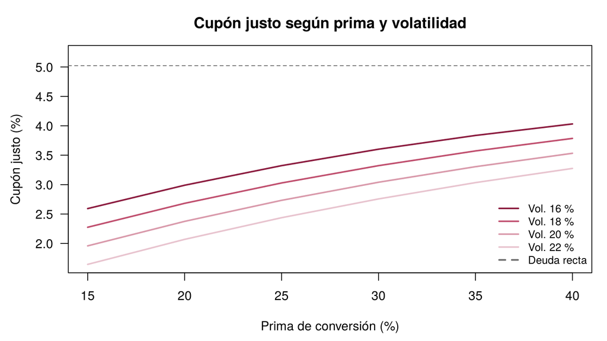

```r
cupon_para <- function(prima, s) {
  K <- S0 * (1 + prima); op <- (nominal_bono / K) * bs_call(S0, K, plazo, rf, q, s)
  uniroot(function(c) bono_recto(c, y_recta, plazo) + op - nominal_bono, c(-0.05, 0.2))$root
}
primas <- seq(0.15, 0.40, 0.05); vols <- c(0.16, 0.18, 0.20, 0.22)
malla <- sapply(vols, function(v) sapply(primas, cupon_para, s = v))
par(mar = c(4.5, 4.5, 3, 1))
matplot(100 * primas, 100 * malla, ylim = c(min(100 * malla), 100 * y_recta + 0.2), type = "l", lty = 1, lwd = 2, col = BERRY[1:4], las = 1,
        xlab = "Prima de conversión (%)", ylab = "Cupón justo (%)", main = "Cupón justo según prima y volatilidad")
abline(h = 100 * y_recta, lty = 2, col = "grey40")
legend("bottomright", c(paste("Vol.", 100 * vols, "%"), "Deuda recta"), col = c(BERRY[1:4], "grey40"),
       lty = c(1, 1, 1, 1, 2), lwd = 2, bty = "n", cex = 0.85)
```

```r
knitr::kable(data.frame(`Prima de conversión` = paste0(100 * primas, " %"), `Precio de conversión` = num(S0 * (1 + primas), 2),
                        `Cupón justo (vol. 20.2 %)` = pct(100 * sapply(primas, cupon_para, s = sigma), 2),
                        `Ahorro anual vs. deuda recta (millones USD)` = num((y_recta - sapply(primas, cupon_para, s = sigma)) * monto_emision / 1e6, 1),
                        check.names = FALSE), align = "rrrr", row.names = FALSE, caption = "¿Qué prima de conversión conviene?")
```

¿Qué prima de conversión conviene?

| Prima de conversión | Precio de conversión | Cupón justo (vol. 20.2 %) | Ahorro anual vs. deuda recta (millones USD) |
| --- | --- | --- | --- |
| 15 % | 110.43 | 1.93 % | 92.8 |
| 20 % | 115.24 | 2.35 % | 80.2 |
| 25 % | 120.04 | 2.71 % | 69.5 |
| 30 % | 124.84 | 3.02 % | 60.2 |
| 35 % | 129.64 | 3.28 % | 52.2 |
| 40 % | 134.44 | 3.51 % | 45.4 |

**¿Qué prima y qué cupón convienen?** Una prima baja da más ahorro de cupón, pero acerca la dilución; una prima alta la aleja, pero el ahorro casi desaparece. Proponemos 25 %, como Molson Coors: es el estándar del mercado para emisores de grado de inversión, mantiene un ahorro relevante y, con el call spread, la dilución efectiva solo empieza a partir de 60 %. Para la colocación proponemos un cupón de 2.75 %, apenas por encima del cupón justo, para asegurar la demanda de los inversionistas.

**No hay almuerzo gratis.** Cada punto más de prima de conversión sube el cupón justo, porque la opción que recibe el inversionista vale menos. Y con más volatilidad la opción vale más, así que el cupón puede bajar. La volatilidad implícita de KO en Bloomberg (alrededor de 20 %) está en la parte media del rango de la gráfica.

## 11. Call spread y prima efectiva

Igual que Molson Coors, Coca-Cola compra calls con strike en el precio de conversión y vende warrants con strike de 60 % de prima. Así la dilución solo empieza cuando la acción supera ese techo.

```r
K_techo  <- S0 * (1 + prima_techo)
acciones_totales <- ratio * monto_emision / nominal_bono
c_compra <- bs_call(S0, K_conv, plazo, rf, q, sigma)
c_venta  <- bs_call(S0, K_techo, plazo, rf, q, sigma_w)
costo_neto <- (c_compra - c_venta) * acciones_totales

knitr::kable(data.frame(
  Concepto = c("Acciones subyacentes", "Strike de las calls compradas", "Strike de los warrants vendidos",
               "Costo de las calls (millones USD)", "Ingreso por los warrants (millones USD)", "Costo neto (millones USD)",
               "Costo neto / emisión", "Años de ahorro de cupón para pagarlo",
               "Molson Coors: costo neto / emisión"),
  Valor = c(num(acciones_totales / 1e6, 1), num(K_conv, 2), num(K_techo, 2), num(c_compra * acciones_totales / 1e6, 1),
            num(c_venta * acciones_totales / 1e6, 1), num(costo_neto / 1e6, 1), pct(100 * costo_neto / monto_emision, 2),
            num(costo_neto / ahorro_anual, 1), pct(100 * 49.7 / 575, 2))), align = "lr", row.names = FALSE)
```

| Concepto | Valor |
| --- | --- |
| Acciones subyacentes | 25.0 |
| Strike de las calls compradas | 120.04 |
| Strike de los warrants vendidos | 153.65 |
| Costo de las calls (millones USD) | 300.6 |
| Ingreso por los warrants (millones USD) | 139.8 |
| Costo neto (millones USD) | 160.8 |
| Costo neto / emisión | 5.36 % |
| Años de ahorro de cupón para pagarlo | 2.3 |
| Molson Coors: costo neto / emisión | 8.64 % |

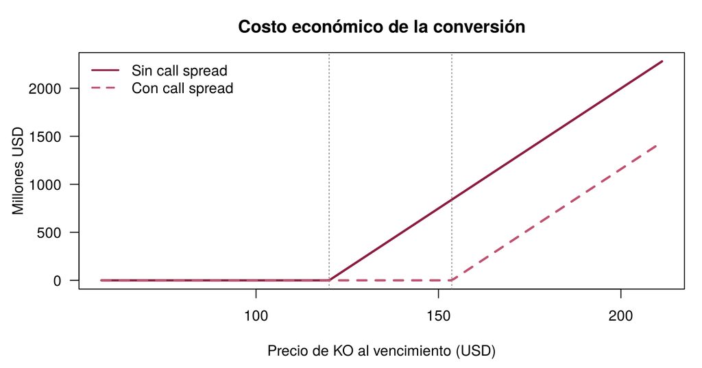

```r
ST <- seq(0.6, 2.2, length.out = 200) * S0
sin_cs <- pmax(ST - K_conv, 0) * acciones_totales / 1e6
con_cs <- pmax(ST - K_techo, 0) * acciones_totales / 1e6
par(mar = c(4.5, 4.5, 3, 1))
plot(ST, sin_cs, type = "l", lwd = 2.5, col = BERRY[1], las = 1, xlab = "Precio de KO al vencimiento (USD)",
     ylab = "Millones USD", main = "Costo económico de la conversión")
lines(ST, con_cs, lwd = 2.5, lty = 2, col = BERRY[2])
abline(v = c(K_conv, K_techo), lty = 3, col = "grey50")
legend("topleft", c("Sin call spread", "Con call spread"), col = BERRY[1:2], lty = c(1, 2), lwd = 2, bty = "n")
```

**Lectura.** Subir la prima efectiva de 25 % a 60 % cuesta 160.8 millones de dólares, el 5.36 % de la emisión, por debajo de lo que pagó Molson Coors en proporción (8.64 %). Cada pierna se valúa con la volatilidad implícita de su propio strike en Bloomberg: 20.2 % para las calls a 120 y 19.9 % para los warrants. Como la volatilidad baja en los strikes altos, el warrant vale un poco menos y Coca-Cola cobra menos por venderlo. Con el ahorro anual de cupón, el call spread se paga en 2.3 años, dentro del plazo de cinco años del bono. A partir de ahí, la empresa conserva el cupón bajo y solo emite acciones nuevas si KO supera 153.65 dólares.

## 12. Cobertura de tasa: T-lock

Mientras se coloca la emisión, una subida en la tasa del Tesoro encarece el financiamiento. El T-lock fija la tasa hoy: si la tasa sube, paga la diferencia; si baja, Coca-Cola paga, pero también se financia más barato.

```r
duracion_mod <- dv01_10mm / 10e6 * 10000   # Duración modificada implícita en el DV01 de Bloomberg SWPM (≈ 4.46)
cambios_pb <- c(-50, -25, 0, 25, 50, 100)
pago <- monto_emision * duracion_mod * cambios_pb / 10000
knitr::kable(data.frame(`Cambio en la tasa (pb)` = cambios_pb,
                        `Pago del T-lock (millones USD)` = num(pago / 1e6, 1),
                        `Mayor costo de la emisión sin cobertura (millones USD)` = num(pago / 1e6, 1),
                        `Resultado neto` = num(0, 1), check.names = FALSE), align = "rrrr", row.names = FALSE)
```

| Cambio en la tasa (pb) | Pago del T-lock (millones USD) | Mayor costo de la emisión sin cobertura (millones USD) | Resultado neto |
| --- | --- | --- | --- |
| -50 | -66.8 | -66.8 | 0.0 |
| -25 | -33.4 | -33.4 | 0.0 |
| 0 | 0.0 | 0.0 | 0.0 |
| 25 | 33.4 | 33.4 | 0.0 |
| 50 | 66.8 | 66.8 | 0.0 |
| 100 | 133.7 | 133.7 | 0.0 |

**Lectura.** El resultado neto es cero en todos los escenarios: lo que el T-lock gana o pierde compensa el cambio en el costo de la emisión. El riesgo es real: en el último año el Tesoro a 5 años se movió entre 3.50 % y 5.09 % (Bloomberg USGG5YR). Con un DV01 de 1.34 millones por punto base, un alza de 25 pb durante la colocación encarecería la emisión en unos 33.4 millones, que el T-lock compensa.

**T-lock o swap con inicio diferido.** El swap SOFR a 5 años (4.40 %) está 28 pb por debajo del Tesoro, un diferencial swap negativo que hoy es normal en el mercado de EUA. Por eso fijar la tasa con un swap de inicio diferido sería un poco más barato, y además deja abierta la opción de pasar después parte de la deuda a tasa flotante. Recomendamos el T-lock para la emisión puntual, igual que Molson Coors, y dejar el swap como alternativa si la empresa quiere mezclar tasa fija y flotante.

## 13. Griegas, escenarios y Monte Carlo

```r
g_compra <- bs_greeks(S0, K_conv,  plazo, rf, q, sigma) * acciones_totales
g_venta  <- bs_greeks(S0, K_techo, plazo, rf, q, sigma_w) * acciones_totales
knitr::kable(data.frame(
  Griega = c("Delta (acciones)", "Gamma (acciones por dólar)", "Vega (USD por punto de volatilidad)"),
  `Calls compradas` = num(g_compra), `Warrants vendidos` = num(g_venta), `Call spread neto` = num(g_compra - g_venta),
  check.names = FALSE), align = "lrrr", row.names = FALSE)
```

| Griega | Calls compradas | Warrants vendidos | Call spread neto |
| --- | --- | --- | --- |
| Delta (acciones) | 11,228,392 | 6,465,060 | 4,763,332 |
| Gamma (acciones por dólar) | 206,019 | 178,942 | 27,077 |
| Vega (USD por punto de volatilidad) | 19,169,576 | 16,419,061 | 2,750,515 |

```r
esc <- c(-0.30, -0.15, 0, 0.15, 0.30, 0.60, 0.80)
valor_cs <- sapply(esc, function(x) (bs_call(S0 * (1 + x), K_conv, plazo - 1, rf, q, sigma) -
                                     bs_call(S0 * (1 + x), K_techo, plazo - 1, rf, q, sigma_w)) * acciones_totales)
knitr::kable(data.frame(`Movimiento de KO` = paste0(ifelse(esc > 0, "+", ""), 100 * esc, " %"), `Precio de KO` = num(S0 * (1 + esc), 2),
                        `Valor del call spread en un año (millones USD)` = num(valor_cs / 1e6, 1),
                        `Ganancia o pérdida vs. costo inicial (millones USD)` = num((valor_cs - costo_neto) / 1e6, 1),
                        check.names = FALSE), align = "rrrr", row.names = FALSE)
```

| Movimiento de KO | Precio de KO | Valor del call spread en un año (millones USD) | Ganancia o pérdida vs. costo inicial (millones USD) |
| --- | --- | --- | --- |
| -30 % | 67.22 | 32.9 | -127.9 |
| -15 % | 81.63 | 80.7 | -80.1 |
| 0 % | 96.03 | 148.2 | -12.7 |
| +15 % | 110.43 | 226.4 | 65.6 |
| +30 % | 124.84 | 306.1 | 145.2 |
| +60 % | 153.65 | 445.7 | 284.9 |
| +80 % | 172.85 | 516.5 | 355.7 |

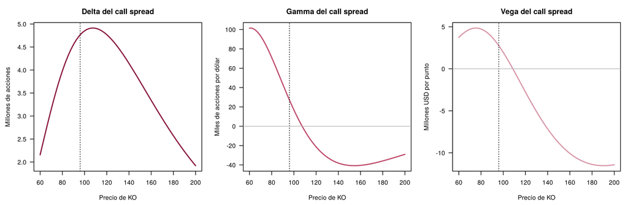

```r
Sg <- seq(60, 200, length.out = 200)
gneto <- t(sapply(Sg, function(s) (bs_greeks(s, K_conv, plazo, rf, q, sigma) - bs_greeks(s, K_techo, plazo, rf, q, sigma_w)) * acciones_totales))
par(mfrow = c(1, 3), mar = c(4.5, 4.5, 3, 1))
plot(Sg, gneto[, "delta"] / 1e6, type = "l", lwd = 2, col = BERRY[1], las = 1, xlab = "Precio de KO", ylab = "Millones de acciones", main = "Delta del call spread"); abline(v = S0, lty = 3)
plot(Sg, gneto[, "gamma"] / 1e3, type = "l", lwd = 2, col = BERRY[2], las = 1, xlab = "Precio de KO", ylab = "Miles de acciones por dólar", main = "Gamma del call spread"); abline(v = S0, lty = 3); abline(h = 0, col = "grey70")
plot(Sg, gneto[, "vega"] / 1e6, type = "l", lwd = 2, col = BERRY[3], las = 1, xlab = "Precio de KO", ylab = "Millones USD por punto", main = "Vega del call spread"); abline(v = S0, lty = 3); abline(h = 0, col = "grey70")
```

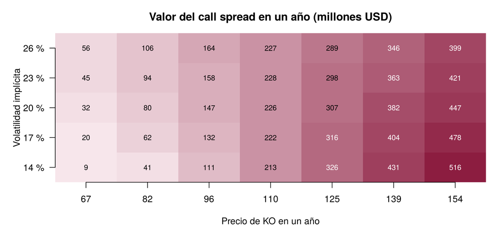

```r
precios_h <- S0 * (1 + c(-0.30, -0.15, 0, 0.15, 0.30, 0.45, 0.60)); vols_h <- c(0.14, 0.17, 0.20, 0.23, 0.26)
H <- sapply(precios_h, function(s) sapply(vols_h, function(v)
  (bs_call(s, K_conv, plazo - 1, rf, q, v) - bs_call(s, K_techo, plazo - 1, rf, q, v - (sigma - sigma_w))) * acciones_totales / 1e6))
par(mar = c(4.5, 5, 3, 1))
image(1:length(precios_h), 1:length(vols_h), t(H), col = colorRampPalette(c("#f7e6eb", BERRY[1]))(30), axes = FALSE,
      xlab = "Precio de KO en un año", ylab = "Volatilidad implícita", main = "Valor del call spread en un año (millones USD)")
axis(1, at = 1:length(precios_h), labels = num(precios_h, 0)); axis(2, at = 1:length(vols_h), labels = pct(100 * vols_h, 0), las = 1)
for (i in seq_along(vols_h)) for (j in seq_along(precios_h)) text(j, i, num(H[i, j], 0), cex = 0.8, col = ifelse(H[i, j] > max(H) * 0.6, "white", "black"))
```

**Lectura.** La delta del call spread es positiva en todo el rango: gana valor cuando KO sube, justo cuando la conversión le cuesta más a la empresa. La gamma y la vega son positivas al precio actual, pero se vuelven negativas cuando KO se acerca al techo, porque ahí pesa más el warrant vendido. El mapa de calor muestra que el valor depende sobre todo del precio y, en menor medida, de la volatilidad. Si KO cae 30 %, el call spread pierde casi todo su valor, pero en ese escenario los bonos tampoco se convierten y no hay dilución que cubrir: la pérdida máxima es la prima pagada.

### Monte Carlo: probabilidad de conversión y costo de la dilución

Se simulan 20,000 trayectorias de KO a cinco años con movimiento browniano geométrico neutral al riesgo. Para cada una se calcula si el bono se convierte y cuánto le cuesta a Coca-Cola la dilución, con y sin call spread.

```r
set.seed(2026); n_sim <- 20000
ST_mc <- S0 * exp((rf - q - 0.5 * sigma^2) * plazo + sigma * sqrt(plazo) * rnorm(n_sim))
costo_sin <- pmax(ST_mc - K_conv, 0) * acciones_totales; costo_con <- pmax(ST_mc - K_techo, 0) * acciones_totales
desc <- exp(-rf * plazo)
knitr::kable(data.frame(
  Concepto = c("Probabilidad de conversión (S > precio de conversión)", "Probabilidad de superar el techo del call spread",
               "VP del costo de dilución sin call spread (millones USD)", "VP del costo de dilución con call spread (millones USD)",
               "VP del call spread por Monte Carlo (millones USD)", "Costo del call spread por Black-Scholes (millones USD)",
               "Costo al vencimiento, percentil 95, sin call spread (millones USD)", "Costo al vencimiento, percentil 95, con call spread (millones USD)"),
  Valor = c(pct(100 * mean(ST_mc > K_conv)), pct(100 * mean(ST_mc > K_techo)), num(desc * mean(costo_sin) / 1e6, 1),
            num(desc * mean(costo_con) / 1e6, 1), num(desc * mean(costo_sin - costo_con) / 1e6, 1), num(costo_neto / 1e6, 1),
            num(quantile(costo_sin, 0.95) / 1e6, 0), num(quantile(costo_con, 0.95) / 1e6, 0))), align = "lr", row.names = FALSE)
```

| Concepto | Valor |
| --- | --- |
| Probabilidad de conversión (S > precio de conversión) | 33.0 % |
| Probabilidad de superar el techo del call spread | 16.3 % |
| VP del costo de dilución sin call spread (millones USD) | 310.6 |
| VP del costo de dilución con call spread (millones USD) | 152.4 |
| VP del call spread por Monte Carlo (millones USD) | 158.1 |
| Costo del call spread por Black-Scholes (millones USD) | 160.8 |
| Costo al vencimiento, percentil 95, sin call spread (millones USD) | 2,195 |
| Costo al vencimiento, percentil 95, con call spread (millones USD) | 1,355 |

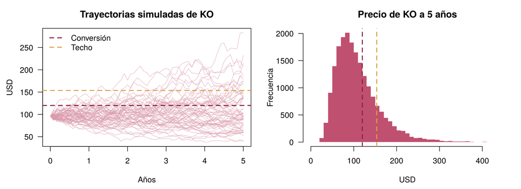

```r
par(mfrow = c(1, 2), mar = c(4.5, 4.5, 3, 1))
tt <- seq(0, plazo, length.out = 61); set.seed(7)
tray <- replicate(60, S0 * exp(cumsum(c(0, (rf - q - 0.5 * sigma^2) * diff(tt) + sigma * sqrt(diff(tt)) * rnorm(60)))))
matplot(tt, tray, type = "l", lty = 1, col = adjustcolor(BERRY[3], 0.6), las = 1, xlab = "Años", ylab = "USD", main = "Trayectorias simuladas de KO")
abline(h = c(K_conv, K_techo), lty = 2, lwd = 2, col = c(BERRY[1], "#d9a441"))
legend("topleft", c("Conversión", "Techo"), lty = 2, lwd = 2, col = c(BERRY[1], "#d9a441"), bty = "n")
hist(ST_mc, breaks = 80, col = BERRY[2], border = NA, las = 1, xlab = "USD", ylab = "Frecuencia", main = "Precio de KO a 5 años", xlim = c(0, 450))
abline(v = c(K_conv, K_techo), lty = 2, lwd = 2, col = c(BERRY[1], "#d9a441"))
```

**Lectura.** El Monte Carlo da un valor del call spread muy cercano al de Black-Scholes; la pequeña diferencia viene de que la simulación usa una sola volatilidad para las dos piernas. La probabilidad de que KO termine por encima del precio de conversión es de 33 % y por encima del techo, de 16 %. En el 5 % de los peores escenarios para la empresa, el call spread reduce el costo de la dilución de 2,195 a 1,355 millones: ese es el seguro que compra Coca-Cola, igual que Molson Coors.

## 14. Implementación en Investopedia

Investopedia no permite operar futuros, swaps ni vender opciones, así que las coberturas se replicaron con ETFs y opciones compradas: acciones de KO con un put (protective put) para el riesgo de la acción, un put de FXE para el tipo de cambio, un put de TLT para la tasa y una call de USO para el costo de la energía. Las posiciones se abrieron el 6 de noviembre y se cerraron el 9 de noviembre de 2026.

```r
ops <- read.csv("datos/operaciones_investopedia.csv", stringsAsFactors = FALSE)
ops$pnl  <- (ops$precio_salida - ops$precio_entrada) * ops$cantidad * ops$multiplicador
ops$rend <- 100 * (ops$precio_salida / ops$precio_entrada - 1)
fmt <- function(x, d) ifelse(is.na(x), "pendiente", num(x, d))
tabla_ops <- function(g) {
  x <- ops[ops$grupo == g, ]
  data.frame(Instrumento = trimws(paste(x$instrumento, ifelse(x$tipo == "Accion", "", paste(x$tipo, x$strike)))),
             Cantidad = x$cantidad, Entrada = fmt(x$precio_entrada, 2), Salida = fmt(x$precio_salida, 2),
             `P&L (USD)` = fmt(x$pnl, 0), `Rendimiento (%)` = fmt(x$rend, 1), Riesgo = x$riesgo_cubierto, check.names = FALSE)
}
knitr::kable(tabla_ops("Cobertura KO"), align = "lrrrrrl", row.names = FALSE, caption = "Portafolio de cobertura de Coca-Cola, 6 al 9 de noviembre")
```

Portafolio de cobertura de Coca-Cola, 6 al 9 de noviembre

| Instrumento | Cantidad | Entrada | Salida | P&L (USD) | Rendimiento (%) | Riesgo |
| --- | --- | --- | --- | --- | --- | --- |
| KO | 1000 | 95.99 | 95.83 | -160 | -0.2 | Precio de la accion |
| KO Put 95 | 10 | 2.33 | 2.15 | -180 | -7.7 | Precio de la accion |
| FXE Put 103 | 10 | 1.05 | 0.45 | -600 | -57.1 | Tipo de cambio |
| TLT Put 82 | 10 | 1.52 | 1.42 | -100 | -6.6 | Tasa de interes |
| USO Call 149 | 10 | 11.45 | 7.95 | -3,500 | -30.6 | Commodities (energia) |

```r
knitr::kable(tabla_ops("Cerrada"), align = "lrrrrrl", row.names = FALSE, caption = "Posiciones de la tarea 6 y de septiembre cerradas el 6 y el 9 de noviembre")
```

Posiciones de la tarea 6 y de septiembre cerradas el 6 y el 9 de noviembre

| Instrumento | Cantidad | Entrada | Salida | P&L (USD) | Rendimiento (%) | Riesgo |
| --- | --- | --- | --- | --- | --- | --- |
| SPY | 40 | 762.99 | 750.41 | -503 | -1.6 | Tarea 6 |
| QQQ Call 685 | 3 | 18.00 | 13.17 | -1,449 | -26.8 | Tarea 6 |
| SPY Put 767 | 1 | 17.07 | 32.61 | 1,554 | 91.0 | Tarea 6 |
| AAPL | 100 | 335.52 | 343.47 | 795 | 2.4 | Tarea de septiembre |

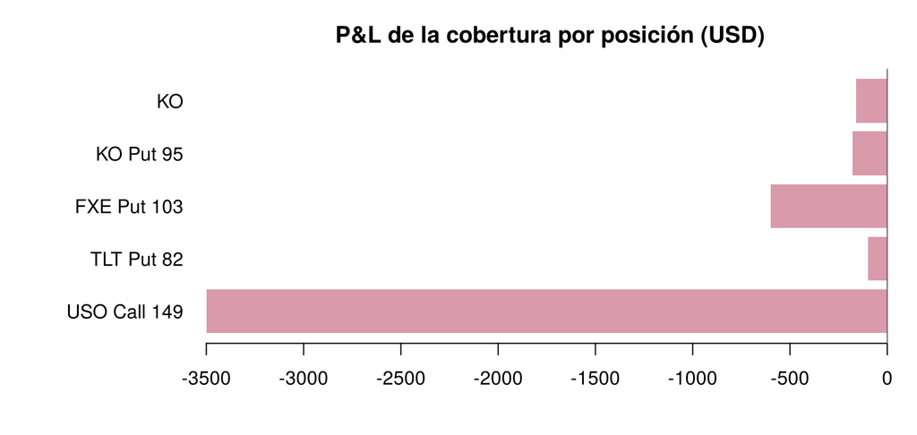

```r
cob <- ops[ops$grupo == "Cobertura KO", ]
etiq <- trimws(paste(cob$instrumento, ifelse(cob$tipo == "Accion", "", paste(cob$tipo, cob$strike))))
par(mar = c(4, 9, 3, 1))
barplot(rev(cob$pnl), names.arg = rev(etiq), horiz = TRUE, las = 1, col = ifelse(rev(cob$pnl) >= 0, BERRY[1], BERRY[3]),
        border = NA, main = "P&L de la cobertura por posición (USD)")
abline(v = 0, col = "grey40")
```

```r
pnl_cob <- sum(cob$pnl); prima_pagada <- sum(cob$precio_entrada[cob$tipo != "Accion"] * cob$cantidad[cob$tipo != "Accion"] * 100)
pp <- sum(cob$pnl[cob$instrumento == "KO"])
```

**Lectura.** Todas las posiciones de cobertura terminaron con pérdida, por un total de 4,540 dólares, el 4.0 % del capital invertido. El protective put de KO perdió 340 dólares: la acción casi no se movió (de 95.99 a 95.83), así que el put no tuvo nada que compensar y perdió valor por el paso del tiempo. FXE y TLT bajaron porque ni el euro ni los bonos se movieron lo suficiente en contra para que los puts ganaran. La call de USO explica tres cuartas partes de la pérdida: el ETF de petróleo bajó y la opción perdió 31 %. Para Coca-Cola, un petróleo más barato significa energía y transporte más baratos, así que en la empresa real esa pérdida se compensaría con menores costos operativos.

### Por qué la cobertura perdió y qué haríamos diferente

**Ningún riesgo se materializó.** Una cobertura con opciones compradas es un seguro: se paga una prima de 16,350 dólares y solo se recupera si el precio se mueve en contra. En tres días KO, el euro, los bonos y el petróleo se movieron poco o a favor de la empresa, así que el resultado fue la prima perdida. Ese es el escenario más probable en un plazo tan corto, y no significa que la cobertura estuviera mal planteada: su objetivo es reducir la variabilidad, no ganar dinero.

**El plazo no coincidió con la exposición.** Las opciones vencen el 18 de diciembre, pero se mantuvieron solo tres días. En ese lapso pesan sobre todo el theta (la pérdida diaria de valor de tiempo) y el diferencial entre compra y venta: se compró al ask y se vendió al bid, lo que en opciones baratas como FXE es una fracción grande del precio. Una tesorería real cubre el horizonte completo del riesgo, por ejemplo los doce meses hasta los vencimientos de 2027.

**El simulador obligó a usar la estructura más cara.** Investopedia solo permite comprar opciones. Una tesorería usaría instrumentos sin prima o casi sin prima: forwards o futuros de divisas y de commodities, un collar (comprar un put y vender una call para financiarlo), o un swap de tasa. Con esas estructuras el costo inicial es cercano a cero y el resultado depende solo del movimiento del subyacente.

**Lo que haríamos diferente.** Primero, medir la cobertura contra la exposición que protege y no por su P&L aislado: el resultado correcto es la variación de la posición cubierta contra la no cubierta. Segundo, dimensionar cada cobertura con una razón de cobertura (delta o beta frente a la exposición real de KO), en lugar de diez contratos iguales para todas. Tercero, usar strikes fuera del dinero o spreads de puts para abaratar la prima, y comprar cuando la volatilidad implícita esté baja. Cuarto, sostener las posiciones el horizonte completo o, si la evaluación es de pocos días, preferir futuros y forwards, que no pierden valor por el tiempo.

## 15. Riesgos de la estrategia

**Supuestos del modelo.** Black-Scholes y el árbol binomial suponen una volatilidad constante durante cinco años, y la tomamos de las opciones listadas más largas (enero de 2029, poco más de dos años), porque no hay opciones listadas a cinco años. Si la volatilidad real de KO sube, la opción entregada vale más y el cupón justo debería ser menor; la gráfica de sensibilidad muestra cuánto. El riesgo de crédito se incluye solo como un diferencial fijo (el CDS a cinco años), sin modelar un posible deterioro de la calificación.

**Riesgo de contraparte.** El call spread se contrata con bancos. Si el banco que vendió las calls no puede pagar cuando KO sube, Coca-Cola queda expuesta a la dilución que quería cubrir. Conviene repartir el call spread entre varias contrapartes con buena calificación.

**Dilución y contabilidad.** Si KO supera el techo de 153.65 dólares, la conversión diluye a los accionistas. Además, el convertible puede requerir separar el componente de capital en los estados financieros y el call spread puede tener tratamiento contable propio, lo que hace la estructura más compleja de explicar a inversionistas.

**Ejecución y simulador.** Las coberturas operativas (divisas, tasas y commodities) se replicaron con ETFs y opciones compradas por las restricciones de Investopedia, que no permite operar futuros, swaps ni vender opciones. Los resultados del simulador ilustran el mecanismo, pero no miden la eficacia de una cobertura corporativa real.

## 16. Recomendación final

**Recomendamos emitir el convertible con call spread y T-lock.** Con los parámetros actuales, Coca-Cola puede refinanciar 3.0 mil millones a un cupón de 2.71 % en lugar de 5.02 %, un ahorro de unos 69.5 millones al año. El call spread cuesta 160.8 millones y se paga con 2.3 años de ese ahorro, mientras eleva la prima efectiva a 60 % y deja la dilución solo para escenarios en que la acción sube más de 60 %. El T-lock fija el costo durante la colocación.

**No hay almuerzo gratis.** El ahorro existe porque Coca-Cola entrega una opción sobre su acción y paga por limitar su efecto. Si la volatilidad implícita baja del 20.2 % que hoy marca Bloomberg, la opción vale menos, el cupón justo sube y el ahorro se reduce; en ese caso la alternativa sería deuda recta con un swap. Antes de emitir, la decisión debe confirmarse con la volatilidad del día de la colocación.

**Para las coberturas operativas**, la lección del simulador es usar instrumentos sin prima (forwards, futuros y collars) para divisas y commodities, dimensionados contra la exposición real y sostenidos durante todo el horizonte del riesgo.

Fuentes: LSEG Workspace (SOV, PEERS, Company Fundamentals, Debt Structure, Issuer Ratings, CDS Overview y StarMine), 3 de noviembre de 2026; Bloomberg (OMON, HIVG, SWPM); The Coca-Cola Company, comunicado de resultados del 3T 2026 (Form 8-K) y Form 10-K; Investopedia Simulator; Yahoo Finance vía `quantmod`. Material académico; no es una recomendación de inversión.